# R Install Guide

Susan VanderPlas

February 27, 2017

## Before you begin

- Contact ITT to gain administrator permissions before attempting to install R and RStudio.
- If you run into issues, log on to Slack and ask for help! Please leave at least the following information:
  - What you were attempting to install
  - Any error messages you have (text/screenshots would be great)

## After you complete the installation:

- Copy the code in this file and paste it into the RStudio Console window (the bottom left).
- If you get any errors, log onto Slack and paste all text output from the console window.

## Installing R

- Download R from http://cran.rstudio.com. [Here](https://cran.rstudio.com/bin/windows/base/R-3.3.2-win.exe) is a link to the R install file at the time this tutorial was written.
- Install this file by running the file as an administrator.
- Download and Install [Rtools](https://cran.rstudio.com/bin/windows/Rtools/) (the most recent version) as an administrator. You do not need to install the packages necessary to compile R, but you should install both the 32 and 64 bit versions of Rtools. Use the default install path (this will simplify your life later)

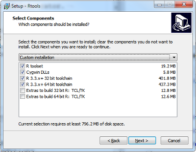

Portions of Rtools to install

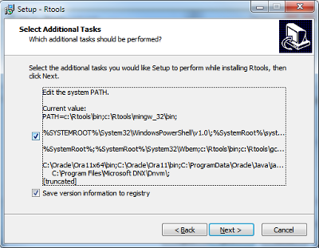

Check the box to alter the system path!!

## Installing RStudio

- Download the free version of [RStudio](https://www.rstudio.com/products/rstudio/download/). Install this as an administrator as well.

## Installing common R packages

- Start RStudio
- Run the following command

```r
source("http://bit.ly/2mvS3Df")
```

This command locates [a script](https://raw.githubusercontent.com/srvanderplas/srvanderplas.github.io/master/Code/InstallPackages.R) I’ve written and stored online that will acquire the most commonly used R packages. You should only run this script if Rtools has installed successfully! If you want to see the script contents, click on the link above.

Some packages may not install if you do not have the following programs installed on your machine:

- [Java Development Kit (JDK)](http://www.oracle.com/technetwork/java/javase/downloads/jdk8-downloads-2133151.html)
- [Perl](http://strawberryperl.com/)

This is generally ok unless you eventually need to use the packages that failed to install. This script is a blunt instrument that is designed to make sure that 90% of the time the packages which you need to use are already installed. You can always install other packages later.

If you install JDK or Perl, you can re-run the script and only the packages which have not already installed successfully will be installed.